# The bug race — does A4 find the planted VerifyOpcode soundness bug, and can Arguzz?

**What this is.** The four fuzzing variants race, on a binary whose *only* planted flaw is a removed `VerifyOpcode*` decode-equality constraint, to **discover that underconstraint**. We record, for every mutation, whether the verifier accepts it and (via the control binary) whether that accept is the planted bug. **No stop-on-first-bug** — full budget, every find and its mutation-index recorded.

**The headline question (race spec §0):** *which variants discover the hole, how often, and at what mutation index?* The hypothesis under test — **A4-surface variants apply `INSTR_TYPE_MOD` and find it; pure-Arguzz variants structurally cannot apply `INSTR_TYPE_MOD` and so never find it** — must be **falsifiable**, and is (every Arguzz accept is control-checked; §5 below).

### Is this "just smoke"? No — read this.

There are three runs; do not conflate them:

- **Ground truth (S0):** 12 certified finds + a negative control through the oracle — *proves the oracle.*
- **Smoke (S1, N=120):** pipeline validation on POS — *that* is the smoke for the real race.
- **Thesis (S2, N=5000 × 4 variants × 10 paired seeds):** **the real result** — the **A4 side** of the complementarity claim. The **other side** is the later **`rs1==rs2` CVE race** (a *real*, value-changing bug) where the mirror is expected: Arguzz/Hybrid find it, pure A4 does not. **The two races together = the full bidirectional complementarity table.** This notebook renders whichever campaign it is pointed at.

### The two oracles (ProG_Report_5 §3.8) — and honest severity

This bug is a **decode** underconstraint, so its finds are **result-preserving** (no journal/`OOPS` change — the rd-write integrity constraint `MemoryWrite` is intact). We therefore use the **internal trace-soundness oracle**: *the control binary rejects the identical mutation specifically at `VerifyOpcode*`.* This is the "fairer-to-A4" oracle; the CVE race will use the **strong application-level oracle** (accepted proof + wrong journal). **This is not a weak result — it is the point:** A4's post-execution surface reaches the **local/decode** constraint family; the value/permutation bugs are Arguzz's domain. A result-preserving decode underconstraint is exactly the kind of bug A4 is built to find.

| variant | mutation surface | scheduler | can it apply `INSTR_TYPE_MOD`? |
| --- | --- | --- | --- |
| **V5_control** | **A4** — post-execution witness/trace-cell mutation | cTS | **yes** |
| **Hybrid_cTS** | **A4 + Arguzz** (15 kinds) | cTS | **yes** |
| **V6_cTS** | **Arguzz** — during-execution fault injection | cTS | **no (structural)** |
| **V6_uniform** | **Arguzz** | round-robin | **no (structural)** |

```python
import os, sys, json
os.chdir("/root/arguzz")
sys.path.insert(0, "/root/arguzz")
import pandas as pd
from a4.runs.iv_pos_9.race import race_lib
RESULTS_DIR = 'a4/runs/iv_pos_9/race/thesis_results'
d = race_lib.load_data(RESULTS_DIR)
print(f"campaign = {d['label']}   N = {d['N']}   seeds done = {d['seeds']}   runs = {len(d['per_run'])}")
print(json.dumps(race_lib.summary(d), indent=2, default=str))
```

```
campaign = thesis   N = 5000   seeds done = [1234, 1235, 1236, 1237, 1238, 1239, 1240, 1241, 1242, 1243]   runs = 40
{
  "results_dir": "a4/runs/iv_pos_9/race/thesis_results",
  "label": "thesis",
  "N": 5000,
  "seeds": [
    1234,
    1235,
    1236,
    1237,
    1238,
    1239,
    1240,
    1241,
    1242,
    1243
  ],
  "n_runs": 40,
  "per_variant": {
    "V5_control": {
      "seeds_done": 10,
      "P_found": 1.0,
      "total_finds": 821,
      "mean_itm_applied": 1213.2,
      "cond_find_density": 0.0676722716782064
    },
    "Hybrid_cTS": {
      "seeds_done": 10,
      "P_found": 1.0,
      "total_finds": 389,
      "mean_itm_applied": 541.0,
      "cond_find_density": 0.07190388170055453
    },
    "V6_cTS": {
      "seeds_done": 10,
      "P_found": 0.0,
      "total_finds": 0,
      "mean_itm_applied": 0.0,
      "cond_find_density": null
    },
    "V6_uniform": {
      "seeds_done": 10,
      "P_found": 0.0,
      "total_finds": 0,
      "mean_itm_applied": 0.0,
      "cond_find_density": null
    }
  }
}
```

## 1. The find signal — what counts as a "find", and why we trust it

A confirmed **planted find** is an `INSTR_TYPE_MOD` accept that is **decode-divergent** (the claimed instruction `(major,minor)` differs from the fetched word's true decode) and that the **clean control binary rejects at `VerifyOpcode*`**. On a binary whose only hole is `VerifyOpcode`, such an accept is control-rejected there *by construction* (F8) — so the notebook counts these structurally (`oracle.is_decode_divergent_itm`, no per-find binary re-run), and the control re-run is a **spot-check**:

- **Ground truth (S0):** 12 such finds were control-confirmed to reject @ `VerifyOpcode`, and 44 result-changers rejected @ `MemoryWrite` (so they never even reach "accept").
- **Falsifier:** every accept — *including* non-`INSTR_TYPE_MOD` ones — is control-checked, so a hypothetical Arguzz accept that rejected @ `VerifyOpcode` *would* be caught. None is expected (§5).
- The one step deferred to a **fast POS node** (where the control proves ~3 s vs ~30 s on the dev box) is a control-confirm **sample** of thesis finds for the final writeup; the structural counts do not depend on it.

**Headline per-variant summary** (live from the DBs):

```python
tbl = race_lib.per_variant_table(d)
def pct(x):  return "—" if x is None else f"{x*100:.2f}%"
def ci(p, lo, hi): return "—" if p is None else f"{p:.2f} [{lo:.2f}, {hi:.2f}]"
rows = [{
    "variant": r["variant"], "surface": r["surface"], "seeds": r["seeds_done"],
    "P(found) [95% CI]": ci(r["P_found"], r["P_found_lo"], r["P_found_hi"]),
    "finds (total)": r["total_finds"], "finds/seed": f"{r['mean_finds']:.1f}",
    "ITM applied/seed": f"{r['mean_itm_applied']:.0f}",
    "P(find|ITM) [95% CI]": (ci(r["cond_find_density"], r["cond_lo"], r["cond_hi"]) if r["cond_find_density"] is not None else "n/a (0 ITM)"),
    "1st-find idx (med)": ("—" if r["first_find_idx_median"] is None else f"{r['first_find_idx_median']:.0f}"),
    "s/mut": f"{r['mean_per_mut_s']:.1f}",
} for r in tbl]
pd.set_option("display.max_colwidth", None)
pd.DataFrame(rows).set_index("variant")
```

| variant | surface | seeds | P(found) [95% CI] | finds (total) | finds/seed | ITM applied/seed | P(find\|ITM) [95% CI] | 1st-find idx (med) | s/mut |
| --- | --- | --- | --- | --- | --- | --- | --- | --- | --- |
| V5_control | A4 | 10 | 1.00 [0.72, 1.00] | 821 | 82.1 | 1213 | 0.07 [0.06, 0.07] | 56 | 3.2 |
| Hybrid_cTS | A4+Arguzz | 10 | 1.00 [0.72, 1.00] | 389 | 38.9 | 541 | 0.07 [0.07, 0.08] | 145 | 3.1 |
| V6_cTS | Arguzz | 10 | 0.00 [0.00, 0.28] | 0 | 0.0 | 0 | n/a (0 ITM) | — | 3.0 |
| V6_uniform | Arguzz | 10 | 0.00 [0.00, 0.28] | 0 | 0.0 | 0 | n/a (0 ITM) | — | 3.0 |

## 2. The headline — A4 reaches the bug; pure Arguzz cannot even apply the mutation

The single clearest result: the planted bug lives behind `INSTR_TYPE_MOD` (a decode-selector edit). The **A4-surface variants apply it hundreds–thousands of times per run and find the hole**; the **pure-Arguzz variants apply it exactly zero times** — `INSTR_TYPE_MOD` is absent from `MUTATION_KINDS_ARGUZZ_*`, so the bug is **off their attack surface entirely**. Left = the reachable surface (ITM applied); right = confirmed finds.

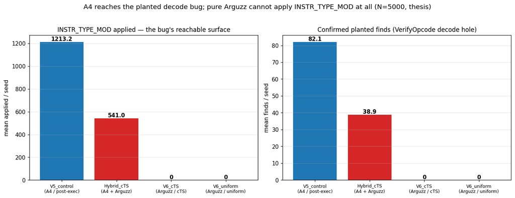

```python
race_lib.show(race_lib.fig_finds_reach(d))
```

## 3. The mechanism — *why* the result is what it is

`P(find) = P(apply INSTR_TYPE_MOD) × P(find | ITM applied)` (ProG_Report_5 §3.7). Decomposing the race into these two factors turns a win/loss into an explanation:

- **P(apply ITM)** — does the scheduler ever apply the bug-relevant mutation? For pure Arguzz this is **identically 0** (structural, F7) → `P(find)=0` *at any budget, no matter how hard it searches*. For A4/Hybrid it is positive (Hybrid lower, since it splits budget across the A4+Arguzz kinds).
- **P(find | ITM)** — given an ITM mutation, how often is it the bug? This is the *bug-intrinsic* rate (only result-coincident decode substitutions accept; the rest reject @ `MemoryWrite`) — measured here, no longer the n=1 ≈4% guess.

The complementarity is in the **first factor**: it is zero for Arguzz by construction.

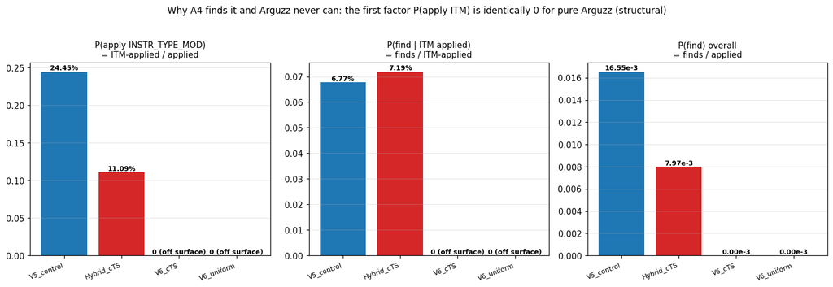

```python
race_lib.show(race_lib.fig_decomposition(d))
```

## 4. Discovery dynamics — how fast, and the survival/CDF view

Two views of *when* the finds happen. Left: **cumulative finds** over the N pulls (the discovery rate; Arguzz lines sit flat on zero). Right: the **mutations-to-first-find CDF** (ProG §3.7's survival framing) — the fraction of seeds that have found the bug by a given mutation index; **censored** seeds (no find in N) never reach 1.0, so the Arguzz curves stay on the floor.

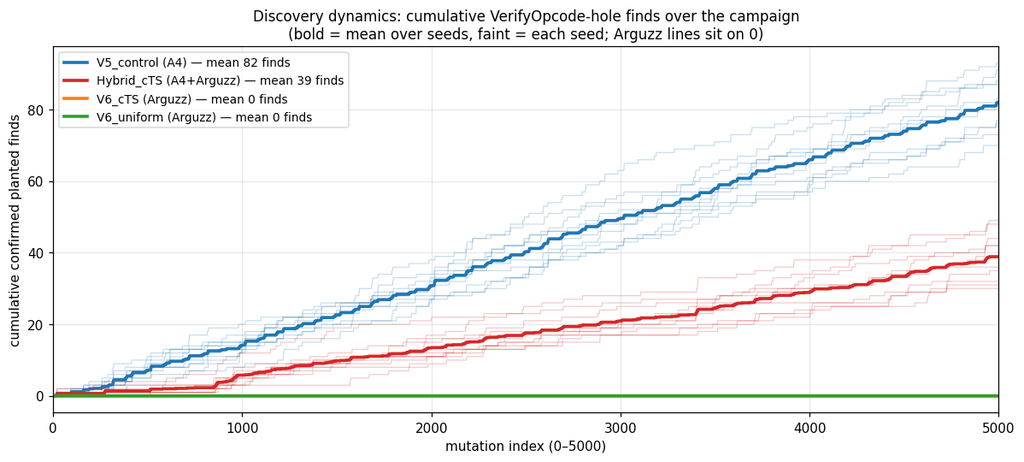

```python
race_lib.show(race_lib.fig_cumulative_finds(d))
```

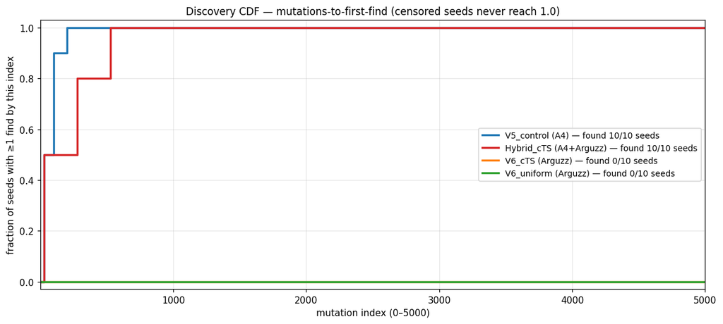

```python
race_lib.show(race_lib.fig_discovery_cdf(d))
```

## 5. The falsifier — Arguzz=0 is *tested*, not assumed

The strong version of "Arguzz can't find it" would be vacuous if we only ever looked at `INSTR_TYPE_MOD`. We don't: **every** accepted mutation — including Arguzz's non-ITM accepts (`INSTR_WORD_MOD`, `POST_EXEC_PC_MOD`, …) — is control-checked. The chart below splits each variant's accepts into **confirmed planted finds** (control rejects @ `VerifyOpcode`) vs **non-planted** (the control accepts them too — benign / no-op). **Every Arguzz accept lands in the non-planted bucket**, so `P(found)=0` is an empirical negative, not an assumption. (A non-planted accept that *had* rejected @ `VerifyOpcode` would have surfaced as a find — the falsifier path exists and stayed empty.)

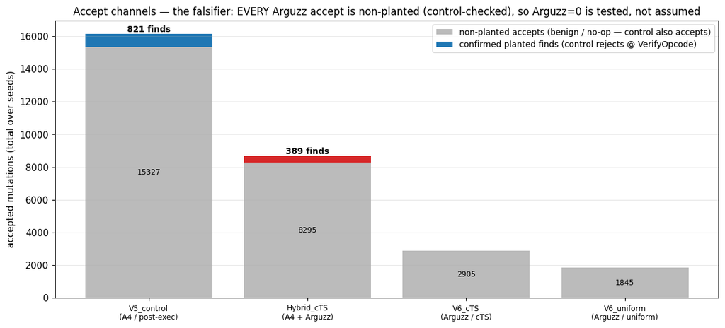

```python
race_lib.show(race_lib.fig_accept_channels(d))
```

```python
# per-run markers (each (variant, seed) campaign)
pr = race_lib.per_run_table(d)
df = pd.DataFrame(pr)
df["conditional_find_density"] = df["conditional_find_density"].map(lambda x: "n/a" if x is None else f"{x*100:.1f}%")
df
```

|  | variant | seed | found | first_find_idx | n_finds | n_applied | n_instr_type_mod_applied | conditional_find_density | n_accepts | n_non_planted |
| --- | --- | --- | --- | --- | --- | --- | --- | --- | --- | --- |
| 0 | V5_control | 1234 | True | 19 | 70 | 4961 | 1206 | 5.8% | 1611 | 1541 |
| 1 | V5_control | 1235 | True | 190 | 81 | 4963 | 1218 | 6.7% | 1604 | 1523 |
| 2 | V5_control | 1236 | True | 18 | 92 | 4961 | 1215 | 7.6% | 1622 | 1530 |
| 3 | V5_control | 1237 | True | 94 | 93 | 4958 | 1193 | 7.8% | 1628 | 1535 |
| 4 | V5_control | 1238 | True | 95 | 76 | 4961 | 1220 | 6.2% | 1608 | 1532 |
| 5 | V5_control | 1239 | True | 99 | 77 | 4962 | 1201 | 6.4% | 1614 | 1537 |
| 6 | V5_control | 1240 | True | 96 | 89 | 4968 | 1204 | 7.4% | 1626 | 1537 |
| 7 | V5_control | 1241 | True | 19 | 87 | 4966 | 1239 | 7.0% | 1620 | 1533 |
| 8 | V5_control | 1242 | True | 17 | 83 | 4956 | 1202 | 6.9% | 1613 | 1530 |
| 9 | V5_control | 1243 | True | 19 | 73 | 4962 | 1234 | 5.9% | 1602 | 1529 |
| 10 | Hybrid_cTS | 1234 | True | 19 | 30 | 4888 | 544 | 5.5% | 851 | 821 |
| 11 | Hybrid_cTS | 1235 | True | 513 | 42 | 4881 | 566 | 7.4% | 861 | 819 |
| 12 | Hybrid_cTS | 1236 | True | 18 | 32 | 4871 | 525 | 6.1% | 870 | 838 |
| 13 | Hybrid_cTS | 1237 | True | 271 | 35 | 4872 | 528 | 6.6% | 878 | 843 |
| 14 | Hybrid_cTS | 1238 | True | 271 | 31 | 4876 | 549 | 5.6% | 847 | 816 |
| 15 | Hybrid_cTS | 1239 | True | 513 | 48 | 4881 | 537 | 8.9% | 855 | 807 |
| 16 | Hybrid_cTS | 1240 | True | 273 | 49 | 4871 | 525 | 9.3% | 891 | 842 |
| 17 | Hybrid_cTS | 1241 | True | 19 | 36 | 4891 | 546 | 6.6% | 886 | 850 |
| 18 | Hybrid_cTS | 1242 | True | 17 | 42 | 4875 | 537 | 7.8% | 870 | 828 |
| 19 | Hybrid_cTS | 1243 | True | 19 | 44 | 4873 | 553 | 8.0% | 875 | 831 |
| 20 | V6_cTS | 1234 | False | 5001 | 0 | 4729 | 0 | nan% | 293 | 293 |
| 21 | V6_cTS | 1235 | False | 5001 | 0 | 4720 | 0 | nan% | 279 | 279 |
| 22 | V6_cTS | 1236 | False | 5001 | 0 | 4745 | 0 | nan% | 306 | 306 |
| 23 | V6_cTS | 1237 | False | 5001 | 0 | 4721 | 0 | nan% | 280 | 280 |
| 24 | V6_cTS | 1238 | False | 5001 | 0 | 4741 | 0 | nan% | 295 | 295 |
| 25 | V6_cTS | 1239 | False | 5001 | 0 | 4738 | 0 | nan% | 287 | 287 |
| 26 | V6_cTS | 1240 | False | 5001 | 0 | 4746 | 0 | nan% | 273 | 273 |
| 27 | V6_cTS | 1241 | False | 5001 | 0 | 4742 | 0 | nan% | 298 | 298 |
| 28 | V6_cTS | 1242 | False | 5001 | 0 | 4757 | 0 | nan% | 289 | 289 |
| 29 | V6_cTS | 1243 | False | 5001 | 0 | 4733 | 0 | nan% | 305 | 305 |
| 30 | V6_uniform | 1234 | False | 5001 | 0 | 4748 | 0 | nan% | 207 | 207 |
| 31 | V6_uniform | 1235 | False | 5001 | 0 | 4753 | 0 | nan% | 163 | 163 |
| 32 | V6_uniform | 1236 | False | 5001 | 0 | 4751 | 0 | nan% | 186 | 186 |
| 33 | V6_uniform | 1237 | False | 5001 | 0 | 4737 | 0 | nan% | 187 | 187 |
| 34 | V6_uniform | 1238 | False | 5001 | 0 | 4715 | 0 | nan% | 181 | 181 |
| 35 | V6_uniform | 1239 | False | 5001 | 0 | 4750 | 0 | nan% | 176 | 176 |
| 36 | V6_uniform | 1240 | False | 5001 | 0 | 4682 | 0 | nan% | 186 | 186 |
| 37 | V6_uniform | 1241 | False | 5001 | 0 | 4718 | 0 | nan% | 182 | 182 |
| 38 | V6_uniform | 1242 | False | 5001 | 0 | 4751 | 0 | nan% | 188 | 188 |
| 39 | V6_uniform | 1243 | False | 5001 | 0 | 4727 | 0 | nan% | 189 | 189 |

## 6. Severity (read honestly) + 7. What this means

**Severity.** The finds are **result-preserving** decode substitutions — the verifier accepts a proof whose instruction-type contradicts the fetched word, with no value change. That is a genuine soundness **underconstraint** (the decode binding is gone) but a **non-propagating, low-severity** one. We report it as such: it is the *decode-family* bug A4's post-execution surface is built to reach, not a value bug.

**The complementarity verdict.**

**On full vs partial data.** When this notebook is built mid-campaign it shows only the finished seeds (see "seeds done" above); the per-variant `P(found)` CIs tighten and the discovery CDFs smooth as the remaining seeds land. Re-running `build_race_notebook.py` at `CHAIN_COMPLETE` regenerates the final figures unchanged in structure. The same script, pointed at the CVE-race DBs (and with the strong oracle swapped in per race-spec §10), produces the mirror analysis.